# homework1

hxp

2021/7/10

# 1

## a

```r
iowa.df <- read.csv("data/Iowa.csv",header=T, sep = ";")
typeof(iowa.df)
```

```
## [1] "list"
```

```r
iowa.df <- as.data.frame(iowa.df)
typeof(iowa.df)
```

```
## [1] "list"
```

## b

```r
nrow(iowa.df)
```

```
## [1] 33
```

```r
ncol(iowa.df)
```

```
## [1] 10
```

行数为33，列数为10

## c

```r
colnames(iowa.df)
```

```
##  [1] "Year"  "Rain0" "Temp1" "Rain1" "Temp2" "Rain2" "Temp3" "Rain3" "Temp4"
## [10] "Yield"
```

每一列的名称

## d

```r
iowa.df[5, 7]
```

```
## [1] 79.7
```

第5行、第7列元素的值

## e

```r
iowa.df[2, ]
```

```
##   Year Rain0 Temp1 Rain1 Temp2 Rain2 Temp3 Rain3 Temp4 Yield
## 2 1931 14.76  57.5  3.83    75  2.72  77.2   3.3  72.6  32.9
```

第2行的全部数据

# 2

## a

第一行合法，因为该向量由字符串元素组成； 第二行合法，因为字符串可以由字典序进行排序； 第三行合法，同样由于字符串可排序； 第四行出错，因为并没有给字符串定义加法故不能求和。

# b

第一行合法，首元素是字符串，对接下来的每一个元素都会进行尝试强制转换为字符串； 第二行非法，因为字符串并没有定义加法；

第三行合法，数据框允许作为其元素的每一个列表有不同类型； 第四行合法，两个数据都是数值类型；

第五行合法，列表元素可以由不同类型组成； 第六行合法，双重方括号的作用是直接取值，两个数值可以直接相加； 第七行非法，单括号返回的值类型为列表（包括名称和值）。

# 3

## a

```r
a <- seq(1, 10000, 372)
a
```

```
##  [1]    1  373  745 1117 1489 1861 2233 2605 2977 3349 3721 4093 4465 4837 5209
## [16] 5581 5953 6325 6697 7069 7441 7813 8185 8557 8929 9301 9673
```

步进为372的等差序列。

```r
a <- seq(1, 10000, (10000 - 1) %/% 49)
a
```

```
##  [1]    1  205  409  613  817 1021 1225 1429 1633 1837 2041 2245 2449 2653 2857
## [16] 3061 3265 3469 3673 3877 4081 4285 4489 4693 4897 5101 5305 5509 5713 5917
## [31] 6121 6325 6529 6733 6937 7141 7345 7549 7753 7957 8161 8365 8569 8773 8977
## [46] 9181 9385 9589 9793 9997
```

```r
length(a)
```

```
## [1] 50
```

元素个数为50个的等差序列。

## b

若指定参数为times，则重复单位为整个原向量； 若指定参数为each，则重复单位为原向量中的每一个元素。

# MB.Ch1.2

```r
library(DAAG)
data(orings)
```

```r
colnames(orings)
```

```
## [1] "Temperature" "Erosion"     "Blowby"      "Total"
```

```r
nrow(orings)
```

```
## [1] 23
```

```r
orings
```

```
##    Temperature Erosion Blowby Total
## 1           53       3      2     5
## 2           57       1      0     1
## 3           58       1      0     1
## 4           63       1      0     1
## 5           66       0      0     0
## 6           67       0      0     0
## 7           67       0      0     0
## 8           67       0      0     0
## 9           68       0      0     0
## 10          69       0      0     0
## 11          70       1      0     1
## 12          70       0      0     0
## 13          70       1      0     1
## 14          70       0      0     0
## 15          72       0      0     0
## 16          73       0      0     0
## 17          75       0      0     0
## 18          75       0      2     1
## 19          76       0      0     0
## 20          76       0      0     0
## 21          78       0      0     0
## 22          79       0      0     0
## 23          81       0      0     0
```

```r
orings_new <- orings[c(1, 2, 4, 11, 13, 18), ]
orings_new
```

```
##    Temperature Erosion Blowby Total
## 1           53       3      2     5
## 2           57       1      0     1
## 4           63       1      0     1
## 11          70       1      0     1
## 13          70       1      0     1
## 18          75       0      2     1
```

```r
which(orings[[4]] > 0)
```

```
## [1]  1  2  3  4 11 13 18
```

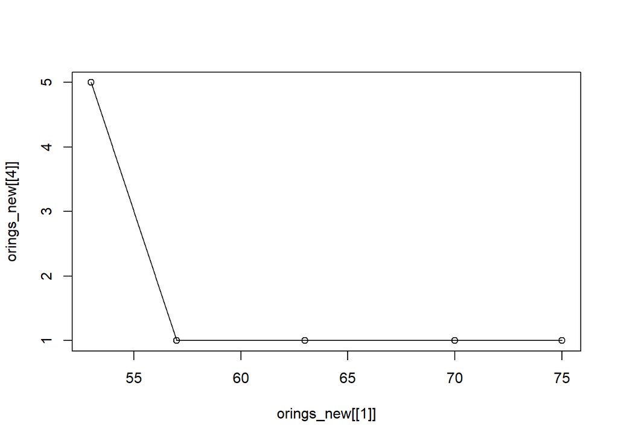

```r
plot(x = orings_new[[1]], y = orings_new[[4]], type = "o")
```

特定数据下温度和总体事故的关系。

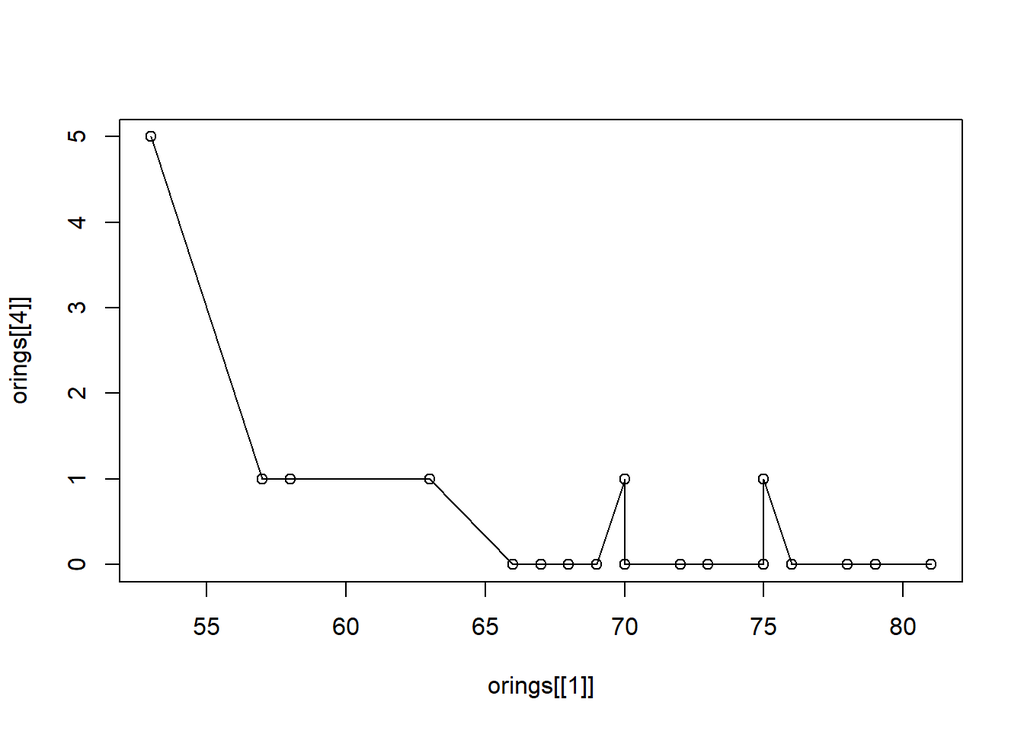

```r
plot(x = orings[[1]], y = orings[[4]], type = "o")
```

全部数据下相应的关系。

# MB.Ch1.4

## (a)

```r
data(ais)
str(ais)
```

```
## 'data.frame':    202 obs. of  13 variables:
##  $ rcc   : num  3.96 4.41 4.14 4.11 4.45 4.1 4.31 4.42 4.3 4.51 ...
##  $ wcc   : num  7.5 8.3 5 5.3 6.8 4.4 5.3 5.7 8.9 4.4 ...
##  $ hc    : num  37.5 38.2 36.4 37.3 41.5 37.4 39.6 39.9 41.1 41.6 ...
##  $ hg    : num  12.3 12.7 11.6 12.6 14 12.5 12.8 13.2 13.5 12.7 ...
##  $ ferr  : num  60 68 21 69 29 42 73 44 41 44 ...
##  $ bmi   : num  20.6 20.7 21.9 21.9 19 ...
##  $ ssf   : num  109.1 102.8 104.6 126.4 80.3 ...
##  $ pcBfat: num  19.8 21.3 19.9 23.7 17.6 ...
##  $ lbm   : num  63.3 58.5 55.4 57.2 53.2 ...
##  $ ht    : num  196 190 178 185 185 ...
##  $ wt    : num  78.9 74.4 69.1 74.9 64.6 63.7 75.2 62.3 66.5 62.9 ...
##  $ sex   : Factor w/ 2 levels "f","m": 1 1 1 1 1 1 1 1 1 1 ...
##  $ sport : Factor w/ 10 levels "B_Ball","Field",..: 1 1 1 1 1 1 1 1 1 1 ...
```

```r
apply(ais, 2, function(x) any(is.na(x)))
```

```
##    rcc    wcc     hc     hg   ferr    bmi    ssf pcBfat    lbm     ht     wt
##  FALSE  FALSE  FALSE  FALSE  FALSE  FALSE  FALSE  FALSE  FALSE  FALSE  FALSE
##    sex  sport
##  FALSE  FALSE
```

不存在含有未知元素NA的列。

## (b)

```r
sport_new <- c()
m_new <- c()
f_new <- c()

ais_sport <- ais[["sport"]][!duplicated(ais[["sport"]])]
# 根据运动分割数据：
for(sport in ais_sport){
  ais_new <- ais[ais[["sport"]] == sport, ]
  sport_new <- c(sport_new, sport)
  tmp <- sum(ais_new[["sex"]] == "m")
  m_new <- c(m_new, tmp)
  f_new <- c(f_new, nrow(ais_new) - tmp)
}
gender.data.frame <- data.frame(sport = sport_new, m = m_new, f = f_new)
gender.data.frame
```

```
##      sport  m  f
## 1   B_Ball 12 13
## 2      Row 15 22
## 3  Netball  0 23
## 4     Swim 13  9
## 5    Field 12  7
## 6   T_400m 18 11
## 7  T_Sprnt 11  4
## 8   Tennis  4  7
## 9      Gym  0  4
## 10  W_Polo 17  0
```

```r
imbalanced_sports <- gender.data.frame[["sport"]][(gender.data.frame[["m"]] / gender.data.frame[["f"]] > 2) | (gender.data.frame[["f"]] / gender.data.frame[["m"]] > 2)]
imbalanced_sports
```

```
## [1] "Netball" "T_Sprnt" "Gym"     "W_Polo"
```

# MB.Ch1.6

## (a)

```r
data(Manitoba.lakes)
Manitoba.lakes
```

```
##                elevation  area
## Winnipeg             217 24387
## Winnipegosis         254  5374
## Manitoba             248  4624
## SouthernIndian       254  2247
## Cedar                253  1353
## Island               227  1223
## Gods                 178  1151
## Cross                207   755
## Playgreen            217   657
```

```r
row.names(Manitoba.lakes)
```

```
## [1] "Winnipeg"       "Winnipegosis"   "Manitoba"       "SouthernIndian"
## [5] "Cedar"          "Island"         "Gods"           "Cross"
## [9] "Playgreen"
```

[figure not shown]

```r
attach(Manitoba.lakes)
plot(log2(area) ~ elevation, pch=16, xlim=c(170,260))
text(log2(area) ~ elevation, labels=row.names(Manitoba.lakes), pos=4)
text(log2(area) ~ elevation, labels=area, pos=2)
title("Manitoba's Largest Lakes")
#mtext("y 轴表示对数尺度", side = 2)
text(183, 11.5, "注意：y 轴为对数尺度，")
text(190, 11, "而点的左边为真实海拔（单位：m）")
```

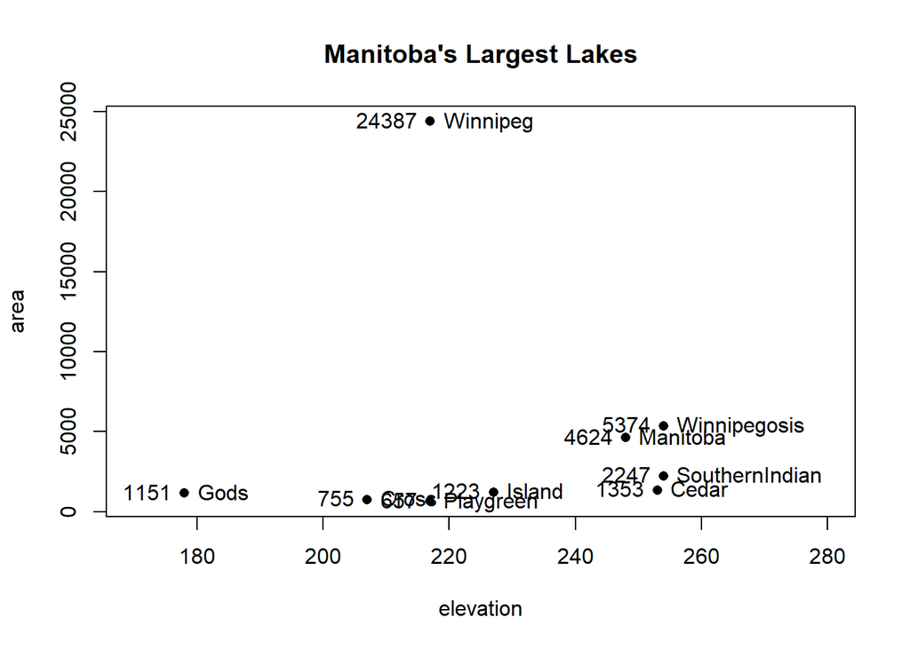

```r
plot(area ~ elevation, pch=16, xlim=c(170,280), ylog=T)
text(area ~ elevation, labels=row.names(Manitoba.lakes), pos=4, ylog=T)
text(area ~ elevation, labels=area, pos=2, ylog=T)
title("Manitoba's Largest Lakes")
```

# MB.Ch1.7

## (a)

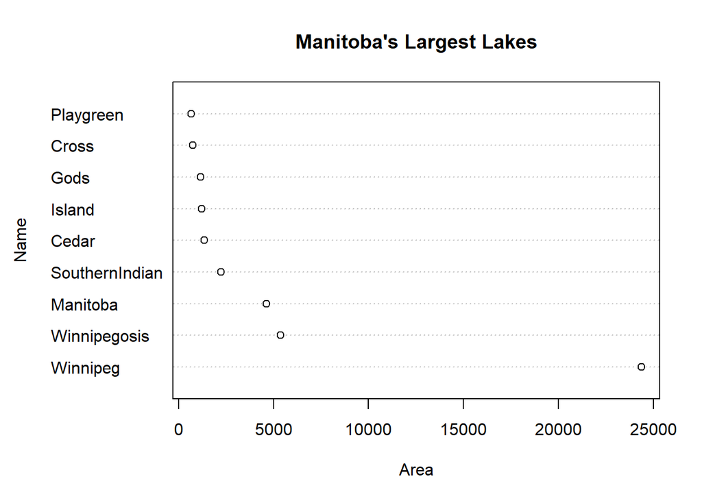

```r
dotchart(area, labels=row.names(Manitoba.lakes), xlab = "Area", ylab = "Name", main = "Manitoba's Largest Lakes")
```

## (b)

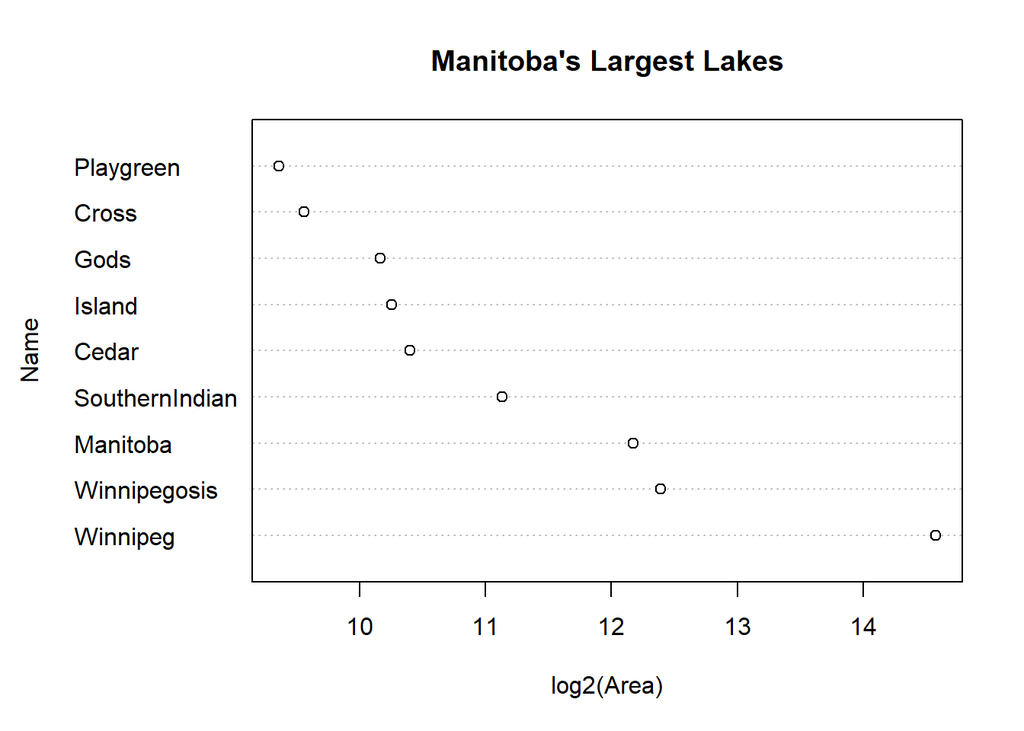

```r
dotchart(log2(area), labels=row.names(Manitoba.lakes), xlab = "log2(Area)", ylab = "Name", main = "Manitoba's Largest Lakes")
```

# MB.Ch1.8

```r
lower_bound <- sum(area)
lower_bound
```

```
## [1] 41771
```